# Department of Agriculture

The FY 2027 proposed budget in context, FY 2018–2027

August 2026

← All agencies

# Overview

This document tracks the budget of the **Department of Agriculture (DA)** across ten fiscal years, FY 2018 to FY 2027, following each peso from the Executive’s proposal (NEP) to enactment (GAA), release (allotment), commitment (obligation), and final cash payment (disbursement). It covers the **Office of the Secretary (OSEC)** in depth and the **nine attached agencies** in a dedicated section, and it is written for **civil-society organizations and advocates scrutinizing the newly released FY 2027 proposal** — ending with full, sortable line-item tables they can interrogate directly.

The headline for FY 2027: the Executive proposes to **cut DA to ₱171.3B department-wide (₱152.0B for the OSEC) — down about ₱14B, roughly 8%, from the FY 2026 enacted level** — even as food security and farm-input costs dominate public debate. But the aggregate hides two moves advocates should focus on. **Farm-to-Market Roads are nearly halved** (₱33B → ₱16B), the single largest change; and the **Locally-Funded and Foreign-Assisted project portfolio grows to over half the OSEC budget** (₱76.9B, 50.6%) — even though it is the category the department has historically absorbed most slowly, disbursing only about a third to a half of what it is given. (This portfolio is an aggregation of many small, often short-lived projects — individually itemized in the budget documents, but collapsed here into one line for clarity.)

This report opens up that core. In addition to the standard analysis it adds three deep-dives the slide format could not carry: the operational core **by service type** (Production Support, Extension, Market Development, R&D, Equipment, Irrigation); the operational core **by commodity** (rice, corn, livestock, high-value crops, and more); and the **two aggregated mega-lines** (Farm-to-Market Roads and the Locally-Funded/Foreign-Assisted portfolio), where most of the money — and most of the delivery risk — now sits.

# 1 Executive summary

**The FY 2027 NEP proposes to *cut* the DA budget** to ₱171.3B department-wide (₱152.0B for the OSEC) — **down about ₱14B, roughly 8%, from the FY 2026 enacted level** — even as food security and farm-input costs dominate public debate.

**Farm-to-Market Roads are nearly halved.** The FMR line falls **₱33B → ₱16B (−₱17B)**, by far the single largest change in the proposal. (FMR is appropriated at DA but implemented by DPWH, and shows zero DA execution every year.)

**Locally-funded and foreign-assisted projects grow to over half the OSEC.** Grouped together they rise **+₱5.3B to ₱76.9B — 50.6% of the entire OSEC budget.** This is an aggregation of many individual projects — often small and short-lived (appearing one year, absent the next), and itemized in the budget documents but collapsed here into one line — and, as a group, it absorbs slowly: disbursement-to-allotment was just **33% (2024) and 53% (2025)**.

**That is the central risk.** The fastest-growing, largest category is also the one the department has historically absorbed most slowly — so the FY 2027 proposal tilts DA further toward money it has struggled to spend.

**The operational core is roughly held or trimmed.** The National Rice Program’s Production Support stays around ₱26B; livestock and corn production support are cut. Several extension, equipment and modernization lines see modest increases.

**Most attached agencies are also cut.** The Philippine Carabao Center, National Meat Inspection Service, Agricultural Credit Policy Council and others fall, with the **Bureau of Fisheries and Aquatic Resources the main exception** (it grows). Attached agencies remain about 11% of the department (₱19.3B proposed for 2027) — and have **no P/A/P-level execution data**, so for them this review is NEP/GAA only.

**Absorption has weakened as the budget grew.** Aggregate OSEC disbursement-to-allotment ran 74–81% from 2018 to 2023, then fell to **70% (2024) and 69% (2025)** — the backdrop against which the proposal loads still more onto the slow-disbursing foreign-assisted portfolio.

> The scrutiny question for advocates: does a smaller DA budget — tilted further toward a fast-churning, slow-disbursing foreign-assisted portfolio and away from farm-to-market roads — match the government’s stated food-security priorities?

# 2 A note on the data

**Period.** FY 2018 through FY 2027. **FY 2027 is the NEP — the Executive’s proposal — only:** not yet debated or enacted, with no execution data. FY 2026 reflects NEP/GAA only. Execution data (Adjusted Allotments, Obligations, Disbursements) is available **for the Office of the Secretary** for 2018–2025, so **the most recent per-P/A/P utilization shown is FY 2025**. **Attached-agency execution data is not available at all**, so those sections are NEP/GAA only — the FY 2027 proposal is exactly the lever advocates can act on before enactment.

**Reading the proposal.** Wherever a chart or table shows FY 2027, the figure is *proposed*. For the OSEC lines, the FY 2025 utilization columns sit alongside the 2027 proposal so a reader can weigh each line’s *track record* against what it is now being handed; for the attached agencies, no such record exists yet.

**Scope.** DA Office of the Secretary (68 P/A/Ps) plus nine attached agencies. **Current New Appropriations only** — this excludes Continuing and Automatic Appropriations and Special Purpose Fund transfers, a point that matters for the FMR discussion below. Nominal pesos.

**Expense classes.** Personnel Services (PS), Maintenance & Other Operating Expenses (MOOE), Financial Expenses (FE, negligible at DA), and Capital Outlays (CO).

**PREXC structure (OSEC).** General Administration (1000), Support to Operations (2000), Production and Marketing Support (3101 — the operational core), Infrastructure Support (3102), Policy Formulation (3103), Regulatory Services (3104), and a Locally-Funded and Foreign-Assisted bucket (3105).

**The service and commodity decomposition.** DA’s operational P/A/Ps are labelled in a regular “{service} on the {commodity} Program” form — e.g. *Production Support Services (PSS) on the National Rice Program*. This report parses that structure to aggregate the operational core two ways: by **service type** (PSS, ESETS, MDS, R&D, PAEF, INS) and by **commodity** (rice, corn, livestock, high-value crops, organic, halal, urban/peri-urban). These cuts cover the commodity operational core (~₱47.6B in 2026); they deliberately exclude FMR, LFP/FAP, administration, and regulatory lines, which are not commodity-tagged.

**Two lines are aggregates of many.** In the source budget documents, both Farm-to-Market Roads and the Locally-Funded and Foreign-Assisted Program are itemized into hundreds of individual sub-projects. Presenting those individually would bury the analysis in small amounts, so each is treated here as a single aggregate line — which is also how they appear in this dataset.

**Absorptive-capacity denominator.** Unless noted, ratios use **Adjusted Allotments** — how well DA spent what was actually placed in its hands, separate from how much of its GAA was transferred out or never released.

# Section 1 — Office of the Secretary

# 3 The aggregate budget

## 3.1 The budget keeps growing

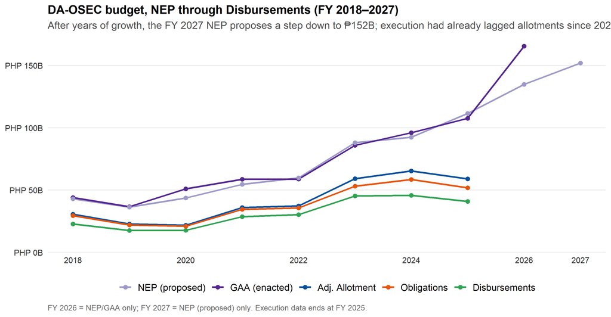

```r
evo <- osec_totals %>% filter(metric %in% c("NEP","GAA","AdjAllot","Obligations","Disbursements")) %>%
  mutate(metric = factor(metric, levels = c("NEP","GAA","AdjAllot","Obligations","Disbursements"),
    labels = c("NEP (proposed)","GAA (enacted)","Adj. Allotment","Obligations","Disbursements")))
ggplot(evo, aes(year, total, color = metric, group = metric)) +
  geom_line(linewidth = 1.0) + geom_point(size = 2) +
  scale_color_manual(values = exec_pal) +
  scale_y_continuous(labels = php_b_axis, breaks = pretty_breaks(6), limits = c(0, NA), expand = expansion(mult = c(0, .05))) +
  scale_x_continuous(breaks = c(seq(2018, 2026, 2), 2027)) +
  labs(title = "DA-OSEC budget, NEP through Disbursements (FY 2018–2027)",
       subtitle = "After years of growth, the FY 2027 NEP proposes a step down to ₱152B; execution had already lagged allotments since 2023",
       x = NULL, y = NULL, caption = "FY 2026 = NEP/GAA only; FY 2027 = NEP (proposed) only. Execution data ends at FY 2025.") +
  theme_da() + guides(color = guide_legend(nrow = 1))
```

The long-run growth is dramatic, but two features matter more for the FY 2027 debate. First, the **widening gap between the allotment line and the disbursement line** after 2023 — money arriving faster than it goes out the door. Second, the **rightmost point: the FY 2027 NEP steps the budget down** from the 2026 enacted peak, even as it leans harder on the slow-disbursing project portfolio (below).

```r
tbl_evo <- osec_totals %>% filter(metric %in% c("NEP","GAA","AdjAllot","Obligations","Disbursements")) %>%
  mutate(value = total/1e9) %>% select(year, metric, value) %>%
  pivot_wider(names_from = year, values_from = value) %>%
  mutate(metric = factor(metric, levels = c("NEP","GAA","AdjAllot","Obligations","Disbursements"),
    labels = c("NEP","GAA","Adj. Allotment","Obligations","Disbursements"))) %>%
  arrange(metric) %>% rename(`PHP B` = metric)
kbl_clean(tbl_evo, font = 13, digits = 1, format.args = list(big.mark = ","), na = "")
```

| PHP B | 2018 | 2019 | 2020 | 2021 | 2022 | 2023 | 2024 | 2025 | 2026 | 2027 |
| --- | --- | --- | --- | --- | --- | --- | --- | --- | --- | --- |
| NEP | 43.0 | 36.3 | 43.7 | 54.6 | 59.8 | 88.1 | 92.4 | 111.5 | 134.9 | 152 |
| GAA | 43.9 | 36.7 | 51.0 | 58.7 | 58.8 | 85.9 | 96.0 | 107.7 | 165.5 |  |
| Adj. Allotment | 30.6 | 22.8 | 21.8 | 35.9 | 37.3 | 59.1 | 65.4 | 59.1 |  |  |
| Obligations | 29.5 | 22.0 | 21.0 | 34.5 | 35.7 | 53.2 | 58.6 | 51.8 |  |  |
| Disbursements | 22.7 | 17.6 | 17.8 | 28.6 | 30.2 | 45.3 | 45.8 | 40.9 |  |  |

## 3.2 Year-on-year growth and the annual augmentation

```r
wide_yr <- osec_totals %>% pivot_wider(names_from = metric, values_from = total)
growth <- wide_yr %>% arrange(year) %>%
  transmute(year, `GAA (B)` = round(GAA/1e9,1), `Growth %` = scales::percent(GAA/lag(GAA) - 1, accuracy = 0.1),
            `NEP (B)` = round(NEP/1e9,1), `Net adj. GAA−NEP (B)` = round((GAA-NEP)/1e9,1))
kbl_clean(growth, font = 13, align = "rrrrr", na = "")
```

| year | GAA (B) | Growth % | NEP (B) | Net adj. GAA−NEP (B) |
| --- | --- | --- | --- | --- |
| 2018 | 43.9 |  | 43.0 | 0.9 |
| 2019 | 36.7 | -16.4% | 36.3 | 0.4 |
| 2020 | 51.0 | 38.8% | 43.7 | 7.3 |
| 2021 | 58.7 | 15.1% | 54.6 | 4.0 |
| 2022 | 58.8 | 0.2% | 59.8 | -1.0 |
| 2023 | 85.9 | 46.1% | 88.1 | -2.2 |
| 2024 | 96.0 | 11.8% | 92.4 | 3.6 |
| 2025 | 107.7 | 12.1% | 111.5 | -3.8 |
| 2026 | 165.5 | 53.7% | 134.9 | 30.6 |
| 2027 |  |  | 152.0 |  |

Congress stayed within about ₱5B of the Executive’s proposal in most years — sometimes trimming (2022, 2023, 2025), sometimes adding. The exception is the proposed **FY 2026 +₱31B Congressional add**, concentrated in the two mega-lines.

# 4 Where the money goes

## 4.1 By PREXC program

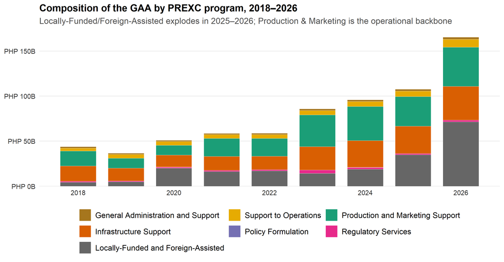

```r
comp <- osec_long %>% filter(metric == "GAA", year <= 2026, !is.na(amount)) %>%
  group_by(year, category) %>% summarise(amount = sum(amount, na.rm = TRUE), .groups = "drop") %>%
  mutate(category = factor(category, levels = names(cat_pal)))
ggplot(comp, aes(year, amount, fill = category)) +
  geom_col(width = 0.75, color = "white", linewidth = 0.2) +
  scale_fill_manual(values = cat_pal) +
  scale_y_continuous(labels = php_b_axis, breaks = pretty_breaks(6), limits = c(0, NA), expand = expansion(mult = c(0, .05))) +
  scale_x_continuous(breaks = seq(2018, 2026, 2)) +
  labs(title = "Composition of the GAA by PREXC program, 2018–2026",
       subtitle = "Locally-Funded/Foreign-Assisted explodes in 2025–2026; Production & Marketing is the operational backbone",
       x = NULL, y = NULL) +
  theme_da() + guides(fill = guide_legend(nrow = 3, byrow = TRUE))
```

```r
comp_pct <- comp %>% group_by(year) %>% mutate(share = round(amount/sum(amount)*100,1)) %>% ungroup() %>%
  select(category, year, share) %>% pivot_wider(names_from = year, values_from = share)
kbl_clean(comp_pct %>% rename(`Program (% of GAA)` = category), font = 12, digits = 1, na = "")
```

| Program (% of GAA) | 2018 | 2019 | 2020 | 2021 | 2022 | 2023 | 2024 | 2025 | 2026 |
| --- | --- | --- | --- | --- | --- | --- | --- | --- | --- |
| General Administration and Support | 3.7 | 3.5 | 2.4 | 2.3 | 2.4 | 2.2 | 2.1 | 1.8 | 1.5 |
| Infrastructure Support | 38.7 | 38.7 | 26.1 | 26.2 | 25.4 | 30.1 | 31.0 | 28.2 | 22.7 |
| Locally-Funded and Foreign-Assisted | 10.2 | 13.4 | 39.4 | 27.9 | 29.1 | 16.6 | 19.8 | 32.5 | 43.3 |
| Policy Formulation | 0.2 | 0.2 | 0.1 | 0.1 | 0.1 | 0.1 | 0.1 | 0.1 | 0.0 |
| Production and Marketing Support | 37.8 | 29.8 | 21.1 | 34.2 | 33.4 | 41.1 | 39.3 | 30.5 | 26.2 |
| Regulatory Services | 2.2 | 2.5 | 2.3 | 2.1 | 2.1 | 4.4 | 1.9 | 1.2 | 1.0 |
| Support to Operations | 7.2 | 11.9 | 8.5 | 7.1 | 7.5 | 5.6 | 5.8 | 5.8 | 5.3 |

## 4.2 By expense class

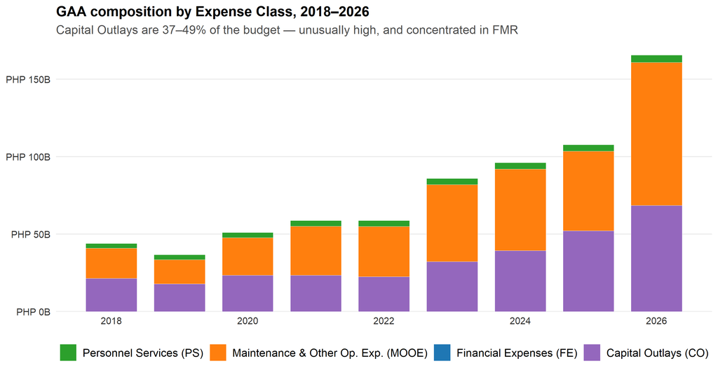

```r
ec_levels <- c("Personnel Services (PS)","Maintenance & Other Op. Exp. (MOOE)","Financial Expenses (FE)","Capital Outlays (CO)")
comp_ec <- df_long_all %>% filter(agency == "Office of the Secretary", metric == "GAA", year <= 2026,
                                  expense_class %in% c("1PS","2MOOE","3FE","6CO")) %>%
  group_by(year, expense_class) %>% summarise(amount = sum(amount, na.rm = TRUE), .groups = "drop") %>%
  mutate(expense_class = factor(expense_class, levels = c("1PS","2MOOE","3FE","6CO"), labels = ec_levels))
ggplot(comp_ec, aes(year, amount, fill = expense_class)) +
  geom_col(width = 0.75, color = "white", linewidth = 0.2) +
  scale_fill_manual(values = ec_pal) +
  scale_y_continuous(labels = php_b_axis, breaks = pretty_breaks(6), limits = c(0, NA), expand = expansion(mult = c(0, .05))) +
  scale_x_continuous(breaks = seq(2018, 2026, 2)) +
  labs(title = "GAA composition by Expense Class, 2018–2026",
       subtitle = "Capital Outlays are 37–49% of the budget — unusually high, and concentrated in FMR",
       x = NULL, y = NULL) +
  theme_da() + guides(fill = guide_legend(nrow = 1))
```

DA is, unusually, a **capital-heavy department**: Capital Outlay runs **37–49% of the GAA** every year, with Personnel Services a sliver (3–9%) and MOOE the rest. But the CO figure is misleading taken at face value: a large share of it is the **FMR line, which is 100% Capital Outlay and records zero execution**. The table separates the two views.

```r
co_tbl <- df_long_all %>% filter(agency == "Office of the Secretary", metric == "GAA",
                                 expense_class %in% c("1PS","2MOOE","3FE","6CO")) %>%
  mutate(isFMR = pap == FMR_LABEL) %>% group_by(year) %>%
  summarise(total = sum(amount, na.rm = TRUE),
            co_all = sum(amount[expense_class == "6CO"], na.rm = TRUE),
            co_exfmr = sum(amount[expense_class == "6CO" & !isFMR], na.rm = TRUE), .groups = "drop") %>%
  transmute(Year = year,
            `CO incl. FMR` = scales::percent(co_all/total, accuracy = 1),
            `CO excl. FMR` = scales::percent(co_exfmr/total, accuracy = 1))
kbl_clean(co_tbl, font = 13, align = "rrr")
```

| Year | CO incl. FMR | CO excl. FMR |
| --- | --- | --- |
| 2018 | 49% | 26% |
| 2019 | 48% | 21% |
| 2020 | 46% | 26% |
| 2021 | 40% | 20% |
| 2022 | 38% | 25% |
| 2023 | 37% | 21% |
| 2024 | 41% | 20% |
| 2025 | 48% | 27% |
| 2026 | 41% | 21% |
| 2027 |  |  |

## 4.3 The ten largest P/A/Ps

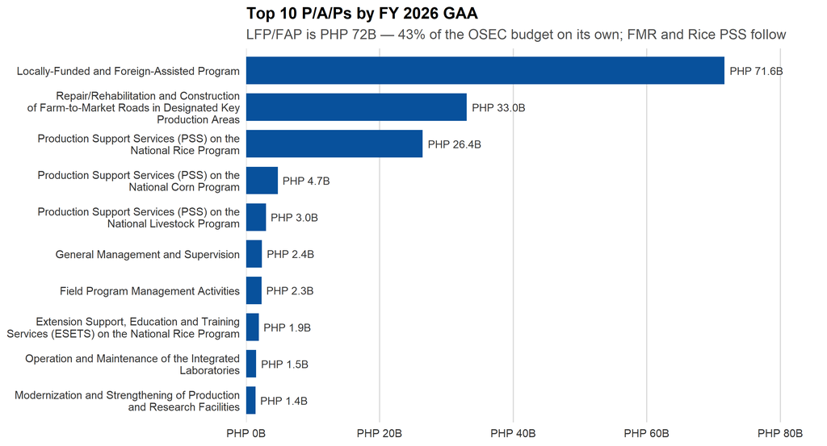

```r
top10 <- osec_pap_year %>% filter(year == 2026, !is.na(GAA), GAA > 0) %>%
  arrange(desc(GAA)) %>% slice_head(n = 10) %>% mutate(pap = factor(pap, levels = rev(pap)))
ggplot(top10, aes(pap, GAA)) +
  geom_col(fill = bar_fill, width = 0.75) +
  geom_text(aes(label = php_b(GAA)), hjust = -0.1, size = 3.3, color = "grey20") +
  coord_flip() +
  scale_x_discrete(labels = function(x) str_wrap(x, 48)) +
  scale_y_continuous(labels = php_b_axis, expand = expansion(mult = c(0, .20)), limits = c(0, NA)) +
  labs(title = "Top 10 P/A/Ps by FY 2026 GAA",
       subtitle = "LFP/FAP is PHP 72B — 43% of the OSEC budget on its own; FMR and Rice PSS follow",
       x = NULL, y = NULL) +
  theme_da() +
  theme(panel.grid.major.y = element_blank(), panel.grid.major.x = element_line(color = "grey85"))
```

### The master table: every OSEC P/A/P, 2025–2027, with its spending record

This is the table built for scrutiny. It lists **every P/A/P in the Office of the Secretary** — not just the top lines — with the proposed and enacted amounts for **FY 2025, 2026, and the new FY 2027 proposal** side by side, and each line’s **most recent actual spending record (FY 2025 utilization)**: what it was allotted, obligated, and disbursed, plus the disbursement rate (**D/A**). Sort by *NEP 2027* to see the proposal’s priorities; sort by *D/A 2025* to see which lines actually spend what they are given. Sortable, searchable, CSV-exportable; amounts in **PHP billions** (the FY 2027 GAA is blank — not yet enacted).

```r
mk <- function(y, m) osec_pap_year %>% filter(year == y) %>% transmute(pap, !!m := .data[[m]]/1e9)
osec_master <- mk(2025,"NEP") %>% rename(`NEP 2025 (B)`=NEP) %>%
  left_join(mk(2025,"GAA") %>% rename(`GAA 2025 (B)`=GAA), by="pap") %>%
  left_join(mk(2026,"NEP") %>% rename(`NEP 2026 (B)`=NEP), by="pap") %>%
  left_join(mk(2026,"GAA") %>% rename(`GAA 2026 (B)`=GAA), by="pap") %>%
  left_join(mk(2027,"NEP") %>% rename(`NEP 2027 (B)`=NEP), by="pap") %>%
  left_join(osec_pap_year %>% filter(year==2025) %>%
              transmute(pap, `Allot 2025 (B)`=AdjAllot/1e9, `Oblig 2025 (B)`=Obligations/1e9,
                        `Disb 2025 (B)`=Disbursements/1e9,
                        `D/A 2025`=ifelse(!is.na(AdjAllot)&AdjAllot>0, Disbursements/AdjAllot, NA_real_)), by="pap") %>%
  mutate(`Proposed chg 26→27 (B)` = `NEP 2027 (B)` - `GAA 2026 (B)`) %>%
  rename(`P/A/P`=pap) %>%
  select(`P/A/P`,`NEP 2025 (B)`,`GAA 2025 (B)`,`NEP 2026 (B)`,`GAA 2026 (B)`,`NEP 2027 (B)`,
         `Proposed chg 26→27 (B)`,`Allot 2025 (B)`,`Oblig 2025 (B)`,`Disb 2025 (B)`,`D/A 2025`) %>%
  arrange(desc(`NEP 2027 (B)`))
dt_table(osec_master, page = 20,
         money_cols = c("NEP 2025 (B)","GAA 2025 (B)","NEP 2026 (B)","GAA 2026 (B)","NEP 2027 (B)",
                        "Proposed chg 26→27 (B)","Allot 2025 (B)","Oblig 2025 (B)","Disb 2025 (B)"),
         pct_cols = "D/A 2025")
```

| P/A/P | NEP 2025 (B) | GAA 2025 (B) | NEP 2026 (B) | GAA 2026 (B) | NEP 2027 (B) | Proposed chg 26→27 (B) | Allot 2025 (B) | Oblig 2025 (B) | Disb 2025 (B) | D/A 2025 |
| --- | --- | --- | --- | --- | --- | --- | --- | --- | --- | --- |
| Locally-Funded and Foreign-Assisted Program | 29.129207 | 35.031585 | 59.48922 | 71.608953 | 76.869129 | 5.260176000000001 | 10.211661 | 7.82314912088 | 5.423664895729999 | 0.5311246520747211 |
| Production Support Services (PSS) on the National Rice Program | 26.088943 | 16.444062 | 26.409838 | 26.409838 | 25.622709 | -0.7871290000000002 | 16.283293 | 16.03095769067 | 13.91196326658 | 0.8543703823655325 |
| Repair/Rehabilitation and Construction of Farm-to-Market Roads in Designated Key Production Areas | 23.18125 | 23.24125 | 16 | 33.009763 | 16 | -17.009763 | 0 | 0 | 0 |  |
| Extension Support, Education and Training Services (ESETS) on the National Rice Program | 2.553067 | 2.465148 | 1.915835 | 1.915835 | 3.328125 | 1.41229 | 2.356911348 | 2.07353191175 | 1.52478323848 | 0.6469412775214828 |
| Provision of Agricultural Equipment and Facilities (PAEF) on the National Corn Program | 1.249025 | 1.249025 | 1.284235 | 1.284235 | 3.03007 | 1.745835 | 1.249025 | 1.19453832892 | 0.8876170209199999 | 0.7106479221152499 |
| Modernization and Strengthening of Production and Research Facilities |  |  | 1.40656 | 1.40656 | 2.867691 | 1.461131 |  |  |  |  |
| Field Program Management Activities | 1.626059 | 1.626059 | 2.330004 | 2.330004 | 2.840961 | 0.5109569999999999 | 1.5736295511 | 1.46427853907 | 1.26623266108 | 0.804657398683748 |
| Production Support Services (PSS) on the National Corn Program | 3.386159 | 3.386159 | 4.741268 | 4.741268 | 2.785448 | -1.95582 | 3.385779945 | 3.36112300842 | 3.1141148292 | 0.9197629142433826 |
| General Management and Supervision | 1.809834 | 1.809834 | 2.374883 | 2.374883 | 2.599674 | 0.2247909999999997 | 2.06745863946 | 2.01921576006 | 1.86556704137 | 0.9023479385576815 |
| Operation and Maintenance of the Integrated Laboratories | 0.887277 | 1.197277 | 1.507235 | 1.507235 | 1.820244 | 0.3130089999999999 | 1.18572725774 | 1.08145653254 | 0.65718733177 | 0.5542483125694531 |

[output cut: 58 more lines]

Blank cells mean no appropriation or no execution record in that year. A line with a large FY 2027 proposal but a low D/A 2025 is where the gap between ambition and delivery is widest — the Locally-Funded/Foreign-Assisted and equipment lines are the ones to watch.

# 5 The FY 2027 proposal: what is cut, what grows

The FY 2027 NEP is the live document advocates can still shape. Department-wide it proposes ₱171.3B — a ₱14B (8%) cut from the 2026 enacted level — but the OSEC reallocation *within* that smaller envelope is the real story.

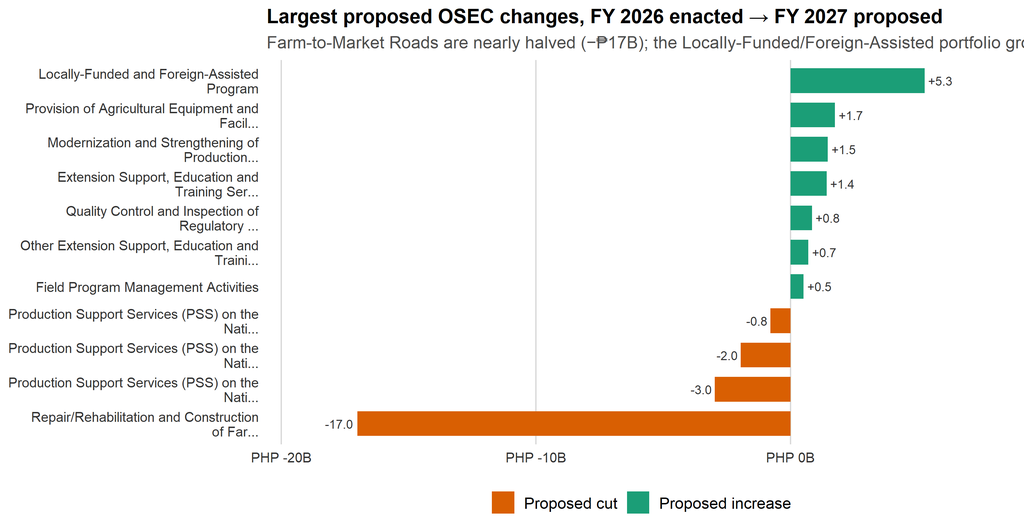

```r
o26 <- osec_pap_year %>% filter(year == 2026) %>% transmute(pap, g26 = GAA)
o27 <- osec_pap_year %>% filter(year == 2027) %>% transmute(pap, n27 = NEP)
chg <- full_join(o26, o27, by = "pap") %>%
  mutate(g26 = coalesce(g26, 0), n27 = coalesce(n27, 0), delta = (n27 - g26)/1e9) %>%
  filter(abs(delta) >= 0.5) %>% arrange(delta) %>%
  mutate(pap = factor(pap, levels = pap),
         dir = ifelse(delta >= 0, "Proposed increase", "Proposed cut"))
ggplot(chg, aes(delta, pap, fill = dir)) +
  geom_col(width = 0.72) +
  geom_text(aes(label = sprintf("%+.1f", delta), hjust = ifelse(delta >= 0, -0.15, 1.15)), size = 3, color = "grey20") +
  scale_fill_manual(values = c("Proposed increase" = "#1B9E77", "Proposed cut" = "#D95F02")) +
  scale_x_continuous(labels = function(v) paste0(peso, v, "B"), expand = expansion(mult = c(0.16, 0.16))) +
  scale_y_discrete(labels = function(x) str_wrap(str_trunc(x, 48), 40)) +
  labs(title = "Largest proposed OSEC changes, FY 2026 enacted → FY 2027 proposed",
       subtitle = "Farm-to-Market Roads are nearly halved (−₱17B); the Locally-Funded/Foreign-Assisted portfolio grows further",
       x = NULL, y = NULL) +
  theme_da() + theme(panel.grid.major.y = element_blank(),
        panel.grid.major.x = element_line(color = "grey85")) +
  guides(fill = guide_legend(nrow = 1))
```

The reallocation has a clear shape. **Farm-to-Market Roads are nearly halved** (₱33B → ₱16B, −₱17B) — by far the single largest change, and a line DA does not execute itself in any case. The money does *not* stay within the smaller total: the **Locally-Funded and Foreign-Assisted portfolio grows by roughly ₱5B to ₱76.9B — over half the entire OSEC budget** — while the operational commodity core is largely held (National Rice Program production support stays around ₱26B) or trimmed (livestock, corn).

## 5.1 The red flag: the largest, fastest-growing line is the weakest absorber

Here is what advocates should press hardest. The Locally-Funded/Foreign-Assisted portfolio is now the biggest thing in the department *and* the thing DA spends least well.

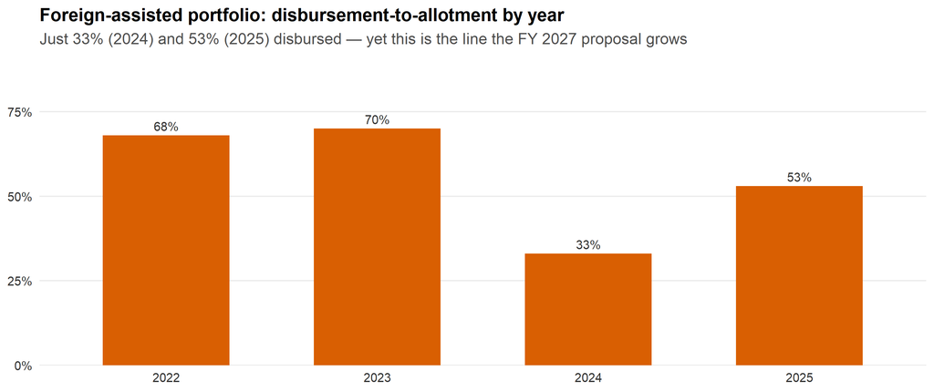

```r
fa_hist <- tibble(
  year = c(2022, 2023, 2024, 2025),
  da = c(0.68, 0.70, 0.33, 0.53))   # FA-group disbursement-to-allotment (verified from OSEC execution)
ggplot(fa_hist, aes(factor(year), da)) +
  geom_col(fill = "#D95F02", width = 0.6) +
  geom_text(aes(label = scales::percent(da, accuracy = 1)), vjust = -0.5, size = 3.4, color = "grey20") +
  scale_y_continuous(labels = percent_format(accuracy = 1), limits = c(0, 0.85), expand = expansion(mult = c(0, 0.08))) +
  labs(title = "Foreign-assisted portfolio: disbursement-to-allotment by year",
       subtitle = "Just 33% (2024) and 53% (2025) disbursed — yet this is the line the FY 2027 proposal grows",
       x = NULL, y = NULL) +
  theme_da()
```

The pattern is the core of the scrutiny case: the FY 2027 proposal **shifts money out of a line DA doesn’t execute (FMR) and into one it disburses at barely a third to a half (foreign-assisted projects)**, while holding the hands-on commodity programs flat. Two questions follow directly: **(1)** what will make the foreign-assisted portfolio disburse faster as it grows past half the budget, and **(2)** is cutting farm-to-market roads by ₱17B consistent with the government’s stated food-security and rural-connectivity goals? The master table above lets advocates trace both questions line by line.

# 6 The operational core by service type

DA’s hands-on commodity work is organised into six “banner” service components. Aggregating every commodity program into these services shows *how* DA delivers, independent of *what* it grows. (This covers the commodity operational core — about ₱47.6B in 2026 — and excludes FMR, LFP/FAP, administration, and regulatory lines.)

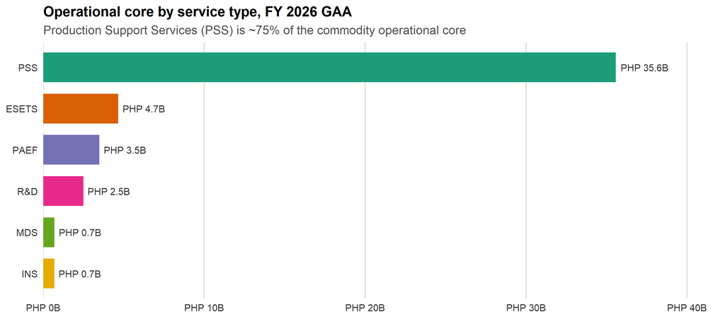

```r
ban_26 <- osec_long %>% filter(metric == "GAA", year == 2026, !is.na(service)) %>%
  group_by(service) %>% summarise(GAA = sum(amount, na.rm = TRUE), .groups = "drop") %>%
  mutate(service = factor(service, levels = rev(SERVICE_LV)))
ggplot(ban_26, aes(service, GAA)) +
  geom_col(aes(fill = as.character(service)), width = 0.72) +
  geom_text(aes(label = php_b(GAA)), hjust = -0.1, size = 3.4, color = "grey20") +
  coord_flip() + scale_fill_manual(values = banner_pal, guide = "none") +
  scale_y_continuous(labels = php_b_axis, expand = expansion(mult = c(0, .18)), limits = c(0, NA)) +
  labs(title = "Operational core by service type, FY 2026 GAA",
       subtitle = "Production Support Services (PSS) is ~75% of the commodity operational core",
       x = NULL, y = NULL) +
  theme_da() + theme(panel.grid.major.y = element_blank(), panel.grid.major.x = element_line(color = "grey85"))
```

PSS — direct production inputs (seeds, fertilizer, planting materials, fingerlings) — dwarfs everything else at ₱35.6B. The training/extension arm (ESETS, ₱4.7B), equipment (PAEF, ₱3.5B), research (R&D, ₱2.5B), market development (MDS, ₱0.7B), and irrigation (INS, ₱0.7B) are all an order of magnitude smaller. DA’s operational model is, in budget terms, overwhelmingly about **distributing production inputs**.

## 6.1 How the service mix has evolved

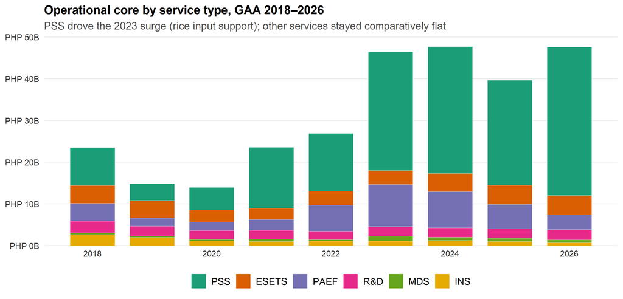

```r
ban_evo <- osec_long %>% filter(metric == "GAA", year <= 2026, !is.na(service)) %>%
  group_by(year, service) %>% summarise(amount = sum(amount, na.rm = TRUE), .groups = "drop") %>%
  mutate(service = factor(service, levels = SERVICE_LV))
ggplot(ban_evo, aes(year, amount, fill = service)) +
  geom_col(width = 0.75, color = "white", linewidth = 0.2) +
  scale_fill_manual(values = banner_pal) +
  scale_y_continuous(labels = php_b_axis, breaks = pretty_breaks(6), limits = c(0, NA), expand = expansion(mult = c(0, .05))) +
  scale_x_continuous(breaks = seq(2018, 2026, 2)) +
  labs(title = "Operational core by service type, GAA 2018–2026",
       subtitle = "PSS drove the 2023 surge (rice input support); other services stayed comparatively flat",
       x = NULL, y = NULL) +
  theme_da() + guides(fill = guide_legend(nrow = 1))
```

The 2023 jump in the operational core is almost entirely **PSS** — the input-subsidy response to food-price and supply pressures, concentrated in rice (next section). The other services have grown only modestly, so the core has become *more* PSS-weighted over time, not less.

## 6.2 Absorption by service type

Here the value of the service cut becomes clear: the weak absorbers are the **capital-type services**.

```r
ban_abs <- osec_long %>% filter(year == 2025, !is.na(service), metric %in% c("AdjAllot","Obligations","Disbursements")) %>%
  group_by(service, metric) %>% summarise(a = sum(amount, na.rm = TRUE), .groups = "drop") %>%
  pivot_wider(names_from = metric, values_from = a) %>%
  transmute(`Service` = service, `Allotment (B)` = round(AdjAllot/1e9,2),
            `Disbursed (B)` = round(Disbursements/1e9,2),
            `O/A` = scales::percent(Obligations/AdjAllot, accuracy = 1),
            `D/A` = scales::percent(Disbursements/AdjAllot, accuracy = 1)) %>%
  arrange(desc(`Allotment (B)`))
kbl_clean(ban_abs, font = 13.5, align = "lrrrr")
```

| Service | Allotment (B) | Disbursed (B) | O/A | D/A |
| --- | --- | --- | --- | --- |
| PSS | 24.99 | 19.67 | 94% | 79% |
| PAEF | 5.81 | 2.38 | 70% | 41% |
| ESETS | 4.47 | 3.17 | 91% | 71% |
| R&D | 1.96 | 1.55 | 93% | 79% |
| INS | 0.99 | 0.55 | 91% | 55% |
| MDS | 0.77 | 0.55 | 87% | 72% |

PSS and R&D disburse at ~79%, ESETS and MDS in the low 70s — but **PAEF (farm equipment) manages only 41%** and **INS (irrigation) 55%**. Both involve physical procurement and construction, which DA struggles to convert into payments within the year — the same capital-execution weakness that shows up in the expense-class view, now located precisely in the equipment and irrigation services.

# 7 The operational core by commodity

Re-cutting the identical operational money by commodity answers a different question: which crops and sectors does DA back?

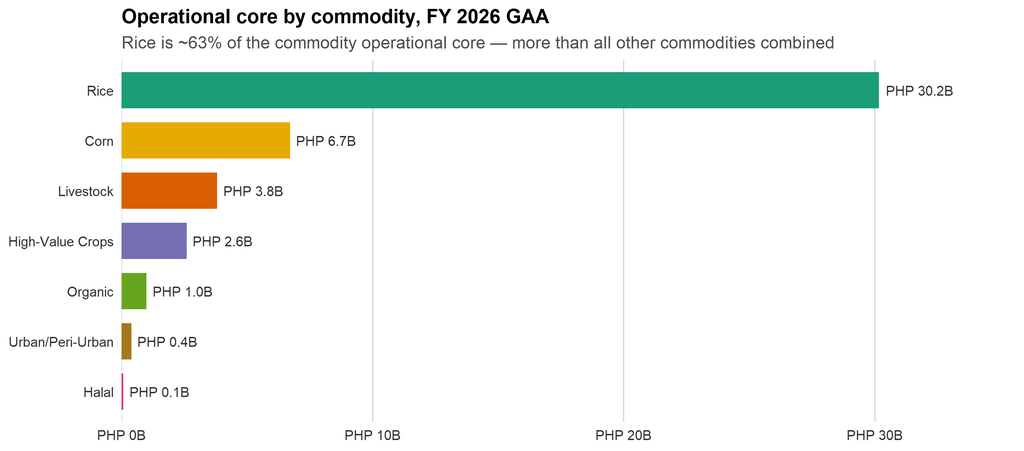

```r
com_26 <- osec_long %>% filter(metric == "GAA", year == 2026, !is.na(commodity)) %>%
  group_by(commodity) %>% summarise(GAA = sum(amount, na.rm = TRUE), .groups = "drop") %>%
  mutate(commodity = factor(commodity, levels = rev(COMMODITY_LV)))
ggplot(com_26, aes(commodity, GAA)) +
  geom_col(aes(fill = as.character(commodity)), width = 0.72) +
  geom_text(aes(label = php_b(GAA)), hjust = -0.1, size = 3.4, color = "grey20") +
  coord_flip() + scale_fill_manual(values = commodity_pal, guide = "none") +
  scale_y_continuous(labels = php_b_axis, expand = expansion(mult = c(0, .18)), limits = c(0, NA)) +
  labs(title = "Operational core by commodity, FY 2026 GAA",
       subtitle = "Rice is ~63% of the commodity operational core — more than all other commodities combined",
       x = NULL, y = NULL) +
  theme_da() + theme(panel.grid.major.y = element_blank(), panel.grid.major.x = element_line(color = "grey85"))
```

Rice (₱30.2B) is larger than every other commodity put together. Corn (₱6.7B) and livestock (₱3.8B) are distant seconds; high-value crops (₱2.6B), organic agriculture (₱1.0B), and the small urban/peri-urban and halal programs trail. Philippine agricultural budgeting is, operationally, **rice budgeting** with everything else at the margin.

## 7.1 How the commodity mix has evolved

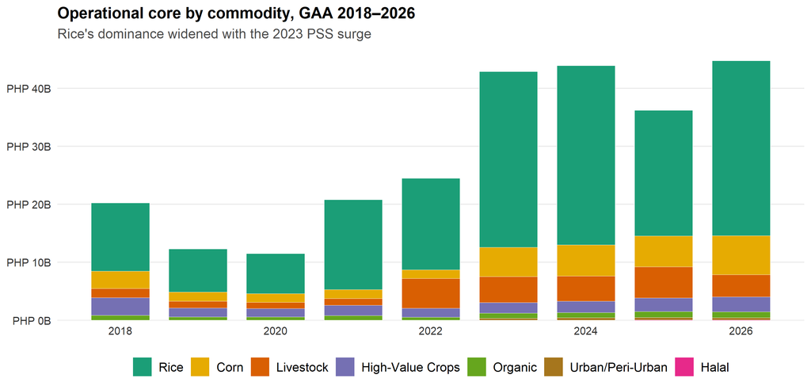

```r
com_evo <- osec_long %>% filter(metric == "GAA", year <= 2026, !is.na(commodity)) %>%
  group_by(year, commodity) %>% summarise(amount = sum(amount, na.rm = TRUE), .groups = "drop") %>%
  mutate(commodity = factor(commodity, levels = COMMODITY_LV))
ggplot(com_evo, aes(year, amount, fill = commodity)) +
  geom_col(width = 0.75, color = "white", linewidth = 0.2) +
  scale_fill_manual(values = commodity_pal) +
  scale_y_continuous(labels = php_b_axis, breaks = pretty_breaks(6), limits = c(0, NA), expand = expansion(mult = c(0, .05))) +
  scale_x_continuous(breaks = seq(2018, 2026, 2)) +
  labs(title = "Operational core by commodity, GAA 2018–2026",
       subtitle = "Rice's dominance widened with the 2023 PSS surge",
       x = NULL, y = NULL) +
  theme_da() + guides(fill = guide_legend(nrow = 1))
```

Rice was always the largest commodity, but its lead *widened* with the 2023 input-support surge. The relative position of corn, livestock, and high-value crops has been broadly stable.

## 7.2 Absorption by commodity

```r
com_abs <- osec_long %>% filter(year == 2025, !is.na(commodity), metric %in% c("AdjAllot","Obligations","Disbursements")) %>%
  group_by(commodity, metric) %>% summarise(a = sum(amount, na.rm = TRUE), .groups = "drop") %>%
  pivot_wider(names_from = metric, values_from = a) %>%
  transmute(`Commodity` = commodity, `Allotment (B)` = round(AdjAllot/1e9,2),
            `Disbursed (B)` = round(Disbursements/1e9,2),
            `O/A` = scales::percent(Obligations/AdjAllot, accuracy = 1),
            `D/A` = scales::percent(Disbursements/AdjAllot, accuracy = 1)) %>%
  arrange(desc(`Allotment (B)`))
kbl_clean(com_abs, font = 13.5, align = "lrrrr")
```

| Commodity | Allotment (B) | Disbursed (B) | O/A | D/A |
| --- | --- | --- | --- | --- |
| Rice | 21.13 | 16.59 | 94% | 79% |
| Livestock | 5.34 | 1.76 | 62% | 33% |
| Corn | 5.31 | 4.48 | 98% | 84% |
| High-Value Crops | 2.34 | 1.39 | 89% | 59% |
| Organic | 1.00 | 0.58 | 92% | 58% |
| Urban/Peri-Urban | 0.44 | 0.32 | 91% | 72% |
| Halal | 0.07 | 0.03 | 61% | 37% |

Absorption varies sharply by commodity. **Corn is the strongest absorber at 84%**, rice a solid 79% — but **livestock disbursed only 33%** of its 2025 allotment, dragged down by its equipment-heavy mix, and high-value crops and organic sit in the high-50s. The commodities that lean on physical procurement (livestock, with large PAEF lines) absorb worst, echoing the service-level finding.

## 7.3 The full picture: service × commodity

The cross-tab below holds both dimensions at once — every cell is a 2026 GAA figure (₱B), with row and column totals. It is the operational core in a single view.

```r
mat <- osec_long %>% filter(metric == "GAA", year == 2026, !is.na(service), !is.na(commodity)) %>%
  group_by(commodity, service) %>% summarise(v = sum(amount, na.rm = TRUE)/1e9, .groups = "drop") %>%
  pivot_wider(names_from = service, values_from = v, values_fill = 0)
# order columns and rows, add totals
svc_present <- intersect(SERVICE_LV, names(mat))
mat <- mat %>% mutate(commodity = factor(commodity, levels = COMMODITY_LV)) %>% arrange(commodity)
mat <- mat %>% select(commodity, all_of(svc_present))
mat$Total <- rowSums(mat[svc_present])
tot_row <- c(list(commodity = "Total"), as.list(round(colSums(mat[c(svc_present,"Total")]), 2)))
mat_disp <- mat %>% mutate(across(all_of(c(svc_present,"Total")), ~round(.,2)))
mat_disp <- bind_rows(mat_disp, as_tibble(tot_row))
kbl_clean(mat_disp %>% rename(`Commodity \\ Service` = commodity), font = 13, align = "lrrrrrr", na = "")
```

| Commodity Service | PSS | ESETS | PAEF | R&D | MDS | INS | Total |
| --- | --- | --- | --- | --- | --- | --- | --- |
| Rice | 26.41 | 1.92 | 0.48 | 0.89 | 0 | 0.46 | 30.16 |
| Corn | 4.74 | 0.42 | 1.28 | 0.17 | 0 | 0.10 | 6.71 |
| Livestock | 2.98 | 0.46 | 0.31 | 0.06 | 0 | 0.00 | 3.81 |
| High-Value Crops | 1.02 | 0.52 | 0.87 | 0.08 | 0 | 0.11 | 2.59 |
| Organic | 0.28 | 0.29 | 0.35 | 0.06 | 0 | 0.02 | 1.00 |
| Urban/Peri-Urban | 0.13 | 0.07 | 0.19 | 0.00 | 0 | 0.00 | 0.39 |
| Halal | 0.01 | 0.05 | 0.01 | 0.00 | 0 | 0.00 | 0.07 |
| Total | 35.57 | 3.73 | 3.49 | 1.26 | 0 | 0.69 | 44.75 |

Reading across rows shows a commodity’s service mix; reading down columns shows a service’s commodity mix. The single largest cell — Rice × PSS — is ₱26.4B, larger than every commodity-total except rice itself.

# 8 The two aggregated mega-lines

Two single P/A/Ps account for ₱104.6B — 63% — of the 2026 OSEC budget. Both are aggregates of hundreds of itemized sub-projects in the source documents, and both raise execution questions.

## 8.1 Farm-to-Market Roads: appropriated, but never executed by DA

```r
fmr <- osec_pap_year %>% filter(pap == FMR_LABEL) %>%
  transmute(FY = year, `GAA (B)` = round(GAA/1e9,1),
            `Allotment (B)` = round(AdjAllot/1e9,2), `Obligations (B)` = round(Obligations/1e9,2),
            `Disbursed (B)` = round(Disbursements/1e9,2))
kbl_clean(fmr, font = 13.5, align = "rrrrr", na = "")
```

| FY | GAA (B) | Allotment (B) | Obligations (B) | Disbursed (B) |
| --- | --- | --- | --- | --- |
| 2018 | 10.0 | 0 | 0 | 0 |
| 2019 | 10.2 | 0 | 0 | 0 |
| 2020 | 10.0 | 0 | 0 | 0 |
| 2021 | 11.7 | 0 | 0 | 0 |
| 2022 | 7.5 | 0 | 0 | 0 |
| 2023 | 14.5 | 0 | 0 | 0 |
| 2024 | 19.6 | 0 | 0 | 0 |
| 2025 | 23.2 | 0 | 0 | 0 |
| 2026 | 33.0 |  |  |  |
| 2027 |  |  |  |  |

Two explanations are consistent with zero recorded DA execution:

1. **Transfer to DPWH.** The FMR appropriation sits in DA’s budget but is transferred to the Department of Public Works and Highways for actual implementation via a memorandum of agreement; the spending then appears in DPWH’s books, not DA’s.
2. **A spill into next year’s Continuing Appropriations.** The funds are retained by DA but not released or disbursed within the budget year, and are instead executed the *following* year under Continuing Appropriations — which this dataset (Current New Appropriations only) does not capture. On this reading, the zero is a symptom of DA being unable to disburse these items in the year they are budgeted.

This dataset cannot distinguish the two: a DPWH transfer and a spill into Continuing Appropriations both leave a zero footprint in DA’s current-year SAAODB. Settling it would require the MOA records or the Continuing-Appropriations execution data, neither of which is in scope here.

Either way, the consequence for this analysis is the same and substantial: roughly **₱33B in 2026 — 20% of the OSEC budget — is appropriated to DA but not executed by DA within the year**. It inflates DA’s apparent Capital-Outlay share (the line is 100% CO) while contributing nothing to measured disbursement, and it is a large part of why DA’s GAA-to-allotment ratio looks so low.

## 8.2 The Locally-Funded and Foreign-Assisted portfolio

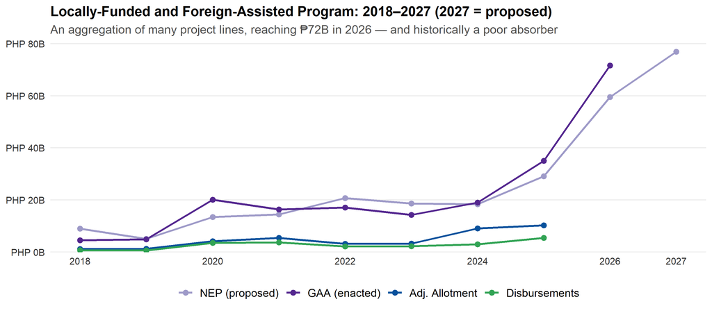

```r
lfp <- osec_pap_year %>% filter(pap == LFP_LABEL) %>%
  select(year, NEP, GAA, AdjAllot, Disbursements) %>%
  pivot_longer(-year, names_to = "metric", values_to = "amount") %>% filter(!is.na(amount)) %>%
  mutate(metric = factor(metric, levels = c("NEP","GAA","AdjAllot","Disbursements"),
    labels = c("NEP (proposed)","GAA (enacted)","Adj. Allotment","Disbursements")))
ggplot(lfp, aes(year, amount, color = metric, group = metric)) +
  geom_line(linewidth = 1.0) + geom_point(size = 2.2) +
  scale_color_manual(values = exec_pal) +
  scale_y_continuous(labels = php_b_axis, breaks = pretty_breaks(5), limits = c(0, NA), expand = expansion(mult = c(0, .05))) +
  scale_x_continuous(breaks = c(seq(2018, 2026, 2), 2027)) +
  labs(title = "Locally-Funded and Foreign-Assisted Program: 2018–2027 (2027 = proposed)",
       subtitle = "An aggregation of many project lines, reaching ₱72B in 2026 — and historically a poor absorber",
       x = NULL, y = NULL) +
  theme_da() + guides(color = guide_legend(nrow = 1))
```

```r
osec_pap_year %>% filter(pap == LFP_LABEL, year %in% 2018:2025) %>%
  transmute(FY = year, `GAA (B)` = round(GAA/1e9,1), `Allotment (B)` = round(AdjAllot/1e9,1),
            `Disbursed (B)` = round(Disbursements/1e9,1),
            `D/A` = scales::percent(Disbursements/AdjAllot, accuracy = 1)) %>%
  kbl_clean(font = 13.5, align = "rrrrr", na = "")
```

| FY | GAA (B) | Allotment (B) | Disbursed (B) | D/A |
| --- | --- | --- | --- | --- |
| 2018 | 4.5 | 1.1 | 0.7 | 61% |
| 2019 | 4.9 | 1.3 | 0.6 | 49% |
| 2020 | 20.1 | 4.1 | 3.5 | 85% |
| 2021 | 16.4 | 5.4 | 3.7 | 68% |
| 2022 | 17.1 | 3.2 | 2.2 | 68% |
| 2023 | 14.2 | 3.2 | 2.2 | 70% |
| 2024 | 19.0 | 9.0 | 2.9 | 33% |
| 2025 | 35.0 | 10.2 | 5.4 | 53% |

# 9 Congressional action: NEP → GAA

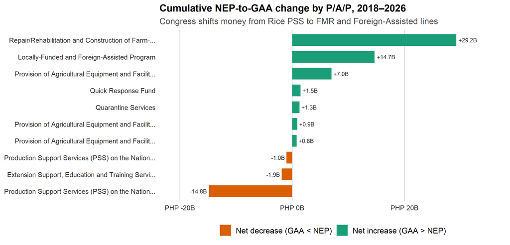

```r
aug <- osec_pap_year %>% filter(year <= 2026) %>% group_by(pap) %>%
  summarise(nep = sum(NEP, na.rm = TRUE), gaa = sum(GAA, na.rm = TRUE), .groups = "drop") %>%
  mutate(change = gaa - nep) %>% filter(abs(change) >= 5e8)
aug_plot <- bind_rows(aug %>% arrange(desc(change)) %>% slice_head(n = 8),
                      aug %>% arrange(change) %>% slice_head(n = 5)) %>% distinct() %>%
  mutate(direction = ifelse(change >= 0, "Net increase (GAA > NEP)", "Net decrease (GAA < NEP)"),
         hj = ifelse(change >= 0, -0.12, 1.12), pap = factor(pap, levels = pap[order(change)]))
ggplot(aug_plot, aes(pap, change/1e9, fill = direction)) +
  geom_col(width = 0.7) +
  geom_text(aes(label = sprintf("%+.1fB", change/1e9), hjust = hj), size = 2.9, color = "grey20") +
  coord_flip() +
  scale_fill_manual(values = c("Net increase (GAA > NEP)" = "#1B9E77", "Net decrease (GAA < NEP)" = "#D95F02")) +
  scale_x_discrete(labels = function(x) str_trunc(x, 50)) +
  scale_y_continuous(labels = function(v) paste0(peso, v, "B"), expand = expansion(mult = c(0.2, 0.2))) +
  labs(title = "Cumulative NEP-to-GAA change by P/A/P, 2018–2026",
       subtitle = "Congress shifts money from Rice PSS to FMR and Foreign-Assisted lines",
       x = NULL, y = NULL) +
  theme_da() +
  theme(panel.grid.major.y = element_blank(), panel.grid.major.x = element_line(color = "grey85")) +
  guides(fill = guide_legend(nrow = 1))
```

```r
aug_full <- osec_pap_year %>% group_by(pap) %>%
  summarise(nep = sum(NEP, na.rm = TRUE), gaa = sum(GAA, na.rm = TRUE), .groups = "drop") %>%
  mutate(change = gaa - nep) %>% filter(abs(change) >= 5e8) %>%
  transmute(`P/A/P` = pap, `Σ NEP (B)` = nep/1e9, `Σ GAA (B)` = gaa/1e9, `Cumulative change (B)` = change/1e9) %>%
  arrange(desc(`Cumulative change (B)`))
dt_table(aug_full, page = 10, money_cols = c("Σ NEP (B)","Σ GAA (B)","Cumulative change (B)"))
```

| P/A/P | Σ NEP (B) | Σ GAA (B) | Cumulative change (B) |
| --- | --- | --- | --- |
| Repair/Rehabilitation and Construction of Farm-to-Market Roads in Designated Key Production Areas | 126.454 | 139.652513 | 13.198513 |
| Provision of Agricultural Equipment and Facilities (PAEF) on the National Rice Program | 9.566367 | 16.329725 | 6.763358 |
| Quarantine Services | 7.285746 | 8.015616 | 0.72987 |
| Quick Response Fund | 9 | 9.5 | 0.5 |
| Production Support Services (PSS) on the National High-Value Crops Development Program | 7.561419 | 6.971779 | -0.58964 |
| Market Development Services | 5.895311 | 5.138275 | -0.757036 |
| Research and Development on the National Rice Program | 7.462731 | 6.694792 | -0.767939 |
| Other Research and Development Activities | 11.65353 | 10.850004 | -0.803526 |
| Development of Organizational Policies, Plans and Procedures | 4.941137 | 4.005114 | -0.936023 |
| Other Extension Support, Education and Training Services (ESETS) Activities | 7.212689 | 5.943753 | -1.268936 |

[output cut: 10 more lines]

# 10 Absorptive capacity

## 10.1 At the aggregate

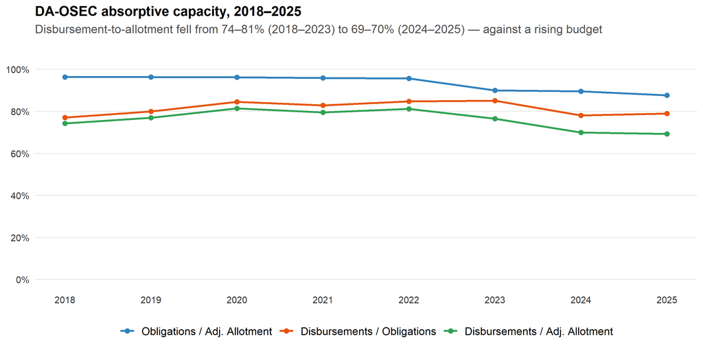

```r
absorp_long <- osec_absorp %>% select(year, oblig_allot, disb_oblig, disb_allot) %>%
  pivot_longer(-year, names_to = "ratio", values_to = "value") %>%
  mutate(ratio = factor(ratio, levels = c("oblig_allot","disb_oblig","disb_allot"),
    labels = c("Obligations / Adj. Allotment","Disbursements / Obligations","Disbursements / Adj. Allotment")))
ggplot(absorp_long, aes(year, value, color = ratio, group = ratio)) +
  geom_line(linewidth = 0.9) + geom_point(size = 2) +
  scale_color_manual(values = absorp_pal) +
  scale_y_continuous(labels = percent_format(accuracy = 1), limits = c(0, 1.08), breaks = seq(0, 1, 0.2)) +
  scale_x_continuous(breaks = 2018:2025) +
  labs(title = "DA-OSEC absorptive capacity, 2018–2025",
       subtitle = "Disbursement-to-allotment fell from 74–81% (2018–2023) to 69–70% (2024–2025) — against a rising budget",
       x = NULL, y = NULL) +
  theme_da() + guides(color = guide_legend(nrow = 1))
```

```r
osec_absorp %>% transmute(Year = year, `Allotment (B)` = round(AdjAllot/1e9,1),
            `Obligations (B)` = round(Obligations/1e9,1), `Disbursements (B)` = round(Disbursements/1e9,1),
            `O/A` = scales::percent(oblig_allot, accuracy = 1), `D/O` = scales::percent(disb_oblig, accuracy = 1),
            `D/A` = scales::percent(disb_allot, accuracy = 1)) %>%
  kbl_clean(font = 13, align = "rrrrrrr")
```

| Year | Allotment (B) | Obligations (B) | Disbursements (B) | O/A | D/O | D/A |
| --- | --- | --- | --- | --- | --- | --- |
| 2018 | 30.6 | 29.5 | 22.7 | 96% | 77% | 74% |
| 2019 | 22.8 | 22.0 | 17.6 | 96% | 80% | 77% |
| 2020 | 21.8 | 21.0 | 17.8 | 96% | 85% | 81% |
| 2021 | 35.9 | 34.5 | 28.6 | 96% | 83% | 80% |
| 2022 | 37.3 | 35.7 | 30.2 | 96% | 85% | 81% |
| 2023 | 59.1 | 53.2 | 45.3 | 90% | 85% | 77% |
| 2024 | 65.4 | 58.6 | 45.8 | 90% | 78% | 70% |
| 2025 | 59.1 | 51.8 | 40.9 | 88% | 79% | 69% |

These ratios use Adjusted Allotments — what DA actually held — so they are *not* depressed by the FMR transfer (FMR never becomes a DA allotment). The decline to 69% is therefore a genuine within-DA delivery story: even setting aside the money that leaves the department, DA is converting a falling share of its releases into payments as the budget climbs.